# Python Foundation

The objective of the class is to provide an introduction to the world of programming, presenting basic computing concepts and getting familiar with the course's dynamics.

### Work Environment

During the course, we will use **Google Colab**, a free tool from Google.

Colab is Google's implementation of [Jupyter Notebook](https://jupyter.org/) that allows us to easily work with Python from any computer using a web browser. For more information about Colabs and how to use them, go to Welcome to Colaboratory.

This environment enables us to combine code, theory, graphics, mathematical equations, and multimedia in a single file, making it easier to distribute and present the topics. Additionally, it allows us to develop the class on a single platform, avoiding compatibility issues with the different computers and operating systems of each participant.

For more information about Colabs and how to use them, go to [Welcome to Colaboratory](https://research.google.com/colaboratory)

NOTE: If you don't have a Google account, you will need to create one to take the course.

### Save the Class in Your Drive

We recommend saving this class in your personal Google Drive so that you can keep your notes and exercises completed during the class.

To do this, you need to click: `File > Save a copy in drive`

Once saved, if you want to continue working, you can open it directly from your Google Drive.

### Introduction to Programming

Programming is the process of designing and building software applications using a language that allows us to communicate instructions to a computer. Essentially, it's how we tell a computer what tasks to perform.

You can think of programming like a black box 🖥️— it receives some data, known as *input*, processes it, and then produces a result, known as *output*. This cycle of input, processing, and output is the core of how computers execute tasks.

### Programming Languages 101

Programming languages are formal systems that let programmers communicate a set of commands to a computer. These commands are processed by the computer's CPU, with the goal of achieving the desired outcome or action. 🎯

Each programming language is built on top of simpler languages, all the way down to the electronics that handle the actual processing.

- **High-level programming languages**: These are easier for humans to work with because they use more abstract and user-friendly instructions. Think of languages like Python or JavaScript that simplify complex operations. 🧑‍💻
- **Assembly language**: A lower-level language specific to a computer's processor. It gets translated into machine code (the famous ones and zeros), which the computer understands directly. 🛠️
- **Bytecode**: Even lower-level, bytecode languages are more challenging to work with. They consist of simpler, hard-to-remember instructions and are closer to what the machine processes. ⚙️
- **Hardware**: At the base of it all is the actual computer hardware, where these binary codes (zeros and ones) are transformed into electrical impulses that the circuits process to perform tasks. 🔌

Programming languages are created to meet specific needs within the tech community. For instance, SQL is designed for database management, while JavaScript is perfect for creating interactive web pages. 🌐

### The Six Main Parts of a Computer:

1. CPU (Central Processing Unit) – The Brain 🧠 The CPU is the computer's brain. It interprets and executes the instructions from software and user inputs, handling basic tasks like opening files, running programs, and performing calculations.
2. RAM (Random Access Memory) – The Desk 📝 RAM acts as a workspace for the CPU, temporarily storing data that the CPU needs quick access to while working. For example, when you open a web browser, the browser's data is stored in RAM so the CPU can fetch it faster. However, this data is erased when the computer shuts down.
3. Hard Drive – The Library 📚 A Hard Drive stores data long-term, even when the computer is turned off. It's where all the software, documents, photos, and videos are saved. When you open a program, the CPU pulls the needed data from the hard drive and stores it in RAM for faster access during use.
4. Input Devices – The Senses 👂 Input devices allow the computer to receive external information, such as through a keyboard, mouse, or microphone. These devices are how you communicate your needs to the computer.
5. Output Devices – The Interaction 🌍 Output devices enable the computer to communicate back with the user. Common output devices include monitors (to display images), printers, and speakers.
6. GPU (Graphics Processing Unit) – The Visual Artist 🎨 The GPU handles the rendering of images, videos, and animations, making it critical for visual tasks. It works alongside the CPU to take over the graphics-heavy processing, making it ideal for gaming, 3D rendering, and machine learning tasks like neural networks.

While the CPU can technically process graphics, the GPU is specifically designed for parallel processing and intensive computations for things like AI.

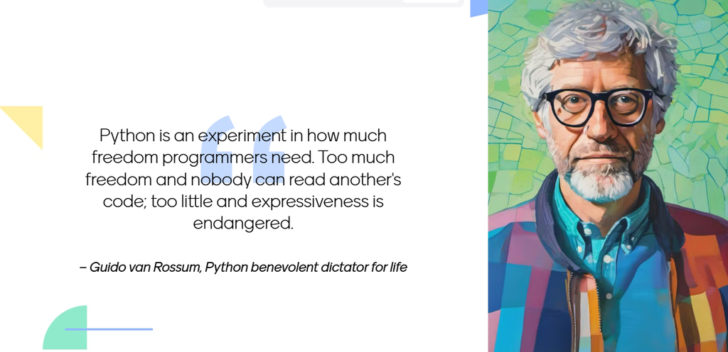

### A Brief History of Python 🐍

Python was created by **Guido van Rossum**, a Dutch programmer, in the late 1980s. While working at the Centrum Wiskunde & Informatica (CWI) in the Netherlands, Guido began developing Python as a successor to the ABC programming language. His aim was to design a language that was easy to read and efficient to use.

In February 1991, the first public version of Python (`0.9.0`) was released, marking the official launch of Python as an open-source project. The language’s name was inspired by the British comedy series *Monty Python's Flying Circus*.

Python continued to evolve, and by January 1994, version `1.0` was released. This version introduced many features that remain fundamental to Python today.

Throughout the late 1990s and early 2000s, Python gained widespread popularity for its simplicity, readability, and versatility. In October 2000, Python `2.0` was released, bringing features like list comprehensions, garbage collection, and support for Unicode.

In December 2008, Python `3.0` was released, introducing significant changes that were not backward-compatible with Python 2, focusing on improving code readability and maintainability.

Currently, Python is actively developing version 3.14, continuing its legacy of being a popular and powerful programming language.

```python
!python --version
```

[output not shown]

## Facts that will make you 💖 Python

Python is an awesome choice for anyone starting out or even for experienced developers! Here’s why: 🚀

### ✨ Free & Open-Source

No need to worry about licensing fees—Python is completely free to use and modify! 💸

The Python project is maintained and developed on Github. You can view its repository at [Github - cpython](https://github.com/python/cpython)

- **Flexible Paradigms**: Python supports various programming styles, like object-oriented, functional, imperative, and procedural. You can pick the one that suits your project best. 🧰
- **High-Level & Interpreted**: Python takes care of a lot of the complex stuff behind the scenes, making it easier for you to focus on coding. Plus, since it’s interpreted, you can run your code right away without needing to compile it! ⚙️
- **Cross-Platform**: Whether you're on Windows, macOS, or Linux, Python works everywhere! 🌍

### ✨ Python is #1 in the TIOBE Index! 📈

Python currently holds the top spot in the TIOBE Index, a well-known ranking of programming languages based on their popularity.

So what exactly is the TIOBE Index, and why does Python’s position matter?

The TIOBE Index tracks the popularity of programming languages by analyzing data from various sources like search engines, online tutorials, coding courses, and job postings. It's updated monthly, providing a snapshot of which languages are most in-demand in the industry. The index doesn't measure which language is better technically, but rather which ones are being actively used and talked about by developers.

Python's #1 spot in the TIOBE Index isn’t just a passing trend—it reflects its dominance and influence across tech industries. Its popularity continues to grow, cementing Python as one of the most important programming languages today! 🥇🐍

[figure not shown]

### ✨ Community

- **Growing Demand**: With Python being the go-to language for AI, data science, and automation, its popularity has skyrocketed, and it's now a must-learn language for many tech professionals. 📊🤖
- **Strong Community and Ecosystem**: Python has an extensive library of frameworks and tools, plus a massive community that contributes to its ongoing growth and innovation. 🌱

#### 🛠️ What is the Python Package Index (PyPI)? 📦

The Python Package Index ([PyPI](https://pypi.org/) ) is like a massive library where you can find tons of ready-to-use software packages created and shared by the Python community. 🚀 These packages are written by developers all around the world to help others solve specific problems or add new features to their Python projects. 🧑‍💻

Here’s why PyPI is awesome:

- Search for Packages: If you need a certain tool or feature, chances are someone has already built it. You can search for packages related to web development, data science, machine learning, automation, and more! 🔍
- Explore Source Code: Not only can you use the package, but you can also check out its source code to see how it's built. This is great for learning or customizing it to fit your needs! 🛠️
- Implementation Guides: Each package on PyPI comes with instructions on how to install and use it. You’ll find details on how to add it to your project, often with examples to get you started quickly. 📖✨
- Project Links: Most packages include links to their documentation, GitHub repositories, and other helpful resources so you can learn more or contribute to the project. 🌐

How to Use PyPI Packages: To actually use any of these packages, you’ll need to install them first. The easiest way to do that is by using pip, Python's package installer. Just run a simple command like:

`pip install package-name`

This will download the package and make it available for your project! 🎉

With PyPI, you can supercharge your Python projects by tapping into a world of pre-built tools and solutions! 💡

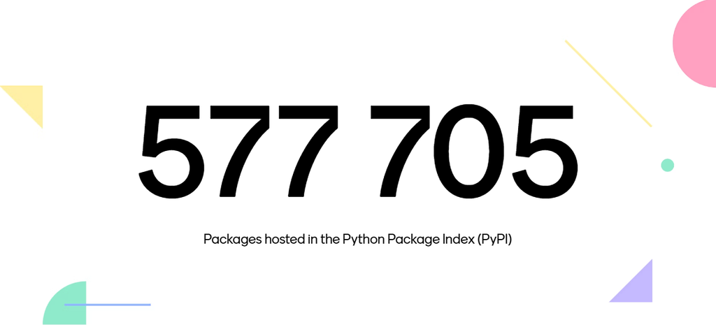

### ✨ Widely Used

Python is trusted by companies worldwide—from startups to tech giants. 🌍

- **Ease of Use**: Python’s simple syntax makes it easy for both beginners and experienced programmers, which has greatly contributed to its widespread adoption.
- **Versatility**: Python is used in many fields—web development, data science, machine learning, automation, and more. This broad range of applications makes it a favorite in various industries.

[figure not shown]

## Python Installation

Installing Python on your computer is important in order to work on real-world projects and operate with an independent instance of Python, rather than using Google Colab.

### [Python.org](https://www.python.org/)

1. Download from the Official Python Website 🌐

The site will automatically detect your operating system (Windows, macOS, or Linux) and suggest the latest version of Python for you. It's best to download the latest stable version (e.g., Python 3.x).

2. Add Python to your PATH (Windows users) to avoid any command-line issues.
3. Consider using a version manager like pyenv if you need multiple Python versions.
4. Verify the installation by checking the version in your terminal. `python --version`
5. Ensure that pip is installed for easy package management. `python -m ensurepip --upgrade`

### Why this method?

- Up-to-date: You’ll always get the latest, secure version of Python.
- Cross-platform: Python.org offers downloads for all operating systems.

### [Anaconda](https://www.anaconda.com/download/)

A comprehensive Python distribution with tools and libraries, great for managing environments and dependencies in data science.

#### Key Features:

- Package Management: Comes with conda, a powerful package and environment manager.
- Comes Bundled with Tools: Includes Jupyter Notebook, Spyder, and many popular libraries like NumPy, Pandas, and Matplotlib.
- Isolated Environments: Lets you easily create and manage multiple Python environments with different versions of Python and packages.

#### Pros:

- Great for managing multiple projects and dependencies.
- Ideal for data-heavy applications and machine learning.

#### Cons:

- Large download size (over 1 GB).
- Not always needed for smaller, general Python projects.

### [PyCharm](https://www.jetbrains.com/pycharm/)

PyCharm is a full-featured Integrated Development Environment (IDE) specifically designed for Python development, created by JetBrains. It has a community edition that is free to use and a professional one that requires a license.

Best for: Professional software development, large projects, and those who want powerful coding features.

#### Key Features:

- Code Assistance: Offers advanced code suggestions, error highlighting, and intelligent refactoring tools. Version Control: Integrated Git and GitHub tools for seamless collaboration.
- Debugging: Powerful debugging tools, including breakpoints, step-through execution, and variable inspection.
- Support for Frameworks: Supports web development frameworks like Django and Flask.

#### Pros:

- Ideal for large-scale projects that require complex code management.
- Tons of features for professional developers, such as code inspection, version control, and project management.

#### Cons:

- Has a learning curve for beginners.
- Can be resource-intensive.

### Why Virtual Environments Are Recommended 🛠️

Imagine your computer is like a kitchen, and you're the chef 👩‍🍳. Every meal (or project) you cook up may need different ingredients 🥦🍗 (Python packages and libraries). Without a virtual environment, all your ingredients are just scattered around in the same pantry. You might end up using the wrong ingredients in your recipe, like accidentally using salt instead of sugar! 😬

A virtual environment is like setting up a separate, custom pantry for each recipe. This way, you keep your ingredients organized for each dish (or project). Each project can have the exact version of Python libraries and dependencies it needs, without conflicting with other projects. 🧂🥣

- **Avoid Conflicts**: Different projects may require different versions of the same library. With virtual environments, these versions stay neatly separated. 🍽️
- **Keep Things Tidy**: It's like having a clean, dedicated workspace for each project. Your global Python installation won’t get cluttered with unused packages. 🧼
- **Portability**: Each virtual environment can be easily shared and recreated, ensuring the project works the same on different machines. 📦🚀

#### Steps to Set Up a Virtual Environment 🛠️

- Install virtualenv (Optional): While Python 3 has a built-in module called venv, you can also use the virtualenv tool. To install it, run: `pip install virtualenv`
- Create a Virtual Environment: To create a virtual environment, navigate to your project folder and run: `python -m venv myenv` Here, myenv is the name of your virtual environment. It’s like building a new pantry for your project. 🍽️
- Activate the Virtual Environment:
  - On Windows:`myenv\Scripts\activate`
  - On macOS/Linux:`source myenv/bin/activate`

  Now you're working in your dedicated virtual environment! Any packages you install will be contained within this environment: `pip install package-name`
- Deactivate the Environment: When you’re done, you can exit the environment by simply typing: `deactivate`

By setting up virtual environments, you ensure every project has its own customized pantry, without risking any ingredient mix-ups between projects! 🍽️🎉

### Version Control with GIT

#### Keeping Your Code Organized and Safe

Version control is like having a magic time machine 🕰️ for your code! It helps you manage and track every change you or your team makes to a project. Whether you're fixing bugs, adding new features, or collaborating with others, version control makes sure nothing gets lost or mixed up. 🙌

One of the most popular tools for version control is [GIT](https://git-scm.com/). With GIT, you can manage your code's versions either through the command line or using graphical interfaces. It also lets you work with cloud services like GitHub, where you can store and share your code with others. We'll be using [GitHub](https://github.com/) in this course to manage and import class projects. 🚀

#### Why Use Version Control?

Version control systems (VCS) offer some great benefits for keeping your code neat and organized:

- **Complete History** 📜: GIT tracks every single change made to your files, from day one of your project. It logs all modifications, deletions, and additions, made by any contributor.
- **Version Management** 🌿: Want to work on a new feature without messing up the main project? No problem! You can create separate branches of your code, then merge them back when you're ready.
- **Traceability** 🔍: You can track who made each change, why it was made, and what impact it had. This helps you spot which changes fixed issues—or introduced new bugs!

#### Basic GIT Concepts 🚦

- **Repository** 🗂️: Think of this as your project’s home. It’s where all your code lives, and GIT keeps a record of every version.
- **Commit** 📝: A snapshot of your changes. For example, "added a new login feature."
- **Push** 📤: Sending your changes from your computer to the cloud (e.g., pushing code to GitHub).
- **Branch** 🌱: A separate version of your project. You can create multiple branches to work on different features without affecting the main code.

By mastering version control with GIT, you'll never have to worry about accidentally overwriting important code or losing track of changes again! 💡👩‍💻

## Basic Programming Concepts

Understanding basic programming concepts is key to learning any programming language. Here are some core ideas that are universal across all languages, regardless of their specific implementation.

#### Variables

A variable is a symbolic name associated with a value that can be used and manipulated in a program. It acts like a container to store data that can be referenced and used throughout the code. Variables are essential because they allow a program to remember and manipulate data.

- **Name**: The identifier used to refer to the variable.
- **Value**: The data or information assigned to the variable. This could be a number, string, or other data types.

```
name = "Alice"  # A string variable storing the value 'Alice'
age = 25  # An integer variable storing the value 25
```

Variables allow the program to dynamically change and handle information as it runs, enabling flexibility and decision-making.

In some programming languages (like C or Java), variables must be declared with a type before use (e.g., int age;). In others, like **Python**, the language automatically infers the type based on the value assigned to it.

Variables can also vary in scope:

- **Local variables**: Declared within a function or block and are only accessible there.
- **Global variables**: Declared outside any function, accessible throughout the program.

#### Data Types

Data types specify the kind of information a variable holds, and each data type defines how the value is stored and the operations that can be performed on it. Different programming languages offer various built-in data types, but most share a few common ones. Let's look at some of the most widely used data types:

- **Integers**

  Whole numbers, positive or negative, without any decimal point. Integers are often used for counting, loops, or index-based operations.
- **Floating-Point Numbers** (Floats)

  Numbers with decimal points, allowing for more precision. Floats are used when precision is required, like for financial calculations or scientific measurements.

  Note: While floats offer precision, they still have limits. Very small or very large numbers may suffer from rounding errors or imprecise representation.
- **Booleans**

  Data type that can hold one of two values: True or False. Booleans are often used for control flow in conditional statements (if, while loops).
- **Strings**

  A sequence of characters, used to represent text. Strings are used for displaying and processing textual information.

  Note: Strings are often treated as an array of characters, allowing operations like slicing and concatenation.
- **Lists/Arrays**

  Ordered collections of items, which can be of the same or different types. Example: [1, 2, 3], ['apple', 'banana', 'cherry']

  Lists and arrays are used to store sequences of data, like user inputs or items in a database.

#### Data Structures

These are sets of variables, each with its data type, grouped within the same variable. For example:

```
class Car:
    engine = '2.0'
    wheels = 4
    doors = 5
```

#### Functions

Functions are a set of programming instructions that receive a set of inputs (which can be empty), perform a series of operations, and return a set of outputs (which can also be empty).

```
def add(a, b):
    return a + b
```

#### Conditional Control Flow

All programming languages have conditional instructions that allow an action to be performed or not depending on a condition. For example, execute the function `add` if the number a is greater than 2, otherwise multiply a by b.

```
def calculate(a, b):
    if a > 2:
        return add(a, b)
    else:
        return a * b
```

#### Iterative Control Flow

There are structures that allow a set of actions to be executed until a condition is met. For example, while `a` is less than 5, add 1 to it.

```
while a < 5:
    a = a + 1
```

### Interpreted and Compiled Languages

Interpreted languages are read almost as written by the programmer and then interpreted into instructions that the computer can understand. Compiled languages, on the other hand, must be processed before they are executed in a process called "compilation." During this process, the code written by programmers is transformed into instructions that the computer can understand, and it is then executed from that file.

Python is an interpreted language

## What´s next?

In the following lessons we´re going to deep dive into Python and you´ll get a better understanding of how it works and the type of things it can be used for.

Here are a few lessons I've picked up along the way that I'd love to share! 🌟

> 1. First off, there’s no such thing as perfect code—just aim to get it done! 🏁 **Done is better than perfect**.
> 2. It´s OK not to know. We can use the resources around like [stack-overflow](https://www.quora.com/Would-I-get-fired-at-Google-or-another-big-tech-firm-if-I-got-caught-using-Stack-Overflow-as-a-reference) or even AI to learn and get better.
> 3. Don´t be afraid of making mistakes and trying things out. Theory and practice are great ways to learn, but you´ll be surprised by the amount of experience that you get from the mistakes. **`Fail` isn´t fail, it is F.A.I.L = First Attempt In Learning**
> 4. if you haven’t tested your code, it might as well be a ticking time bomb! 💣
> 5. The best solutions are often the simplest ones, so don’t overcomplicate things.
> 6. Keep in mind that over-engineering can be worse than having messy code. It’s all about finding that sweet spot!
> 7. Got a pesky bug in your code that just won’t budge? 🐛 Here’s a tip: step away for a bit! Go sleep on it, play some foosball, or take a walk. 🚶‍♂️ You’d be surprised how often the solution pops into your head after a little break —9 times out of 10, in fact! The other 1 out of 10 times? Well, you might just be out of luck. 😅
> 8. It might sound a bit strange, but my advice is to code less and think more! 💭 Once you crank out some poorly thought-out code, you’ll find yourself digging through it line-by-line, refactoring and deleting things, which is never a fun experience. So keep this in mind: the easiest code to get rid of is the code that was never written! ✨

Happy coding! 😊